# Unidad 6 — Algoritmos de Intersección de Conjuntos

Actividad 6.6.1

Autor/a

Mario Galván Rosales

Fecha de publicación

20 de mayo de 2026

# Introducción

Este reporte continúa el trabajo de la unidad anterior, pero ahora con un problema distinto: en lugar de buscar un elemento dentro de una lista ordenada, lo que me interesa es calcular la **intersección entre varias listas ordenadas**. Es una operación que aparece todo el tiempo en motores de búsqueda: cuando uno escribe varias palabras en una consulta, el sistema toma la lista de documentos asociada a cada palabra (la *posting list* de cada término en el índice invertido) y devuelve solo los documentos que aparecen en todas las listas a la vez. Esa intersección es justamente el problema que voy a estudiar acá.

Al igual que con la búsqueda, no existe un algoritmo único que sea siempre el mejor. El comportamiento depende mucho de los tamaños relativos de las listas: cuando son parecidas, un *merge* lineal clásico es suficiente; cuando una lista es mucho más chica que la otra, conviene una estrategia que aproveche esa asimetría. Y cuando hay más de dos listas (consultas con tres o cuatro términos, por ejemplo), aparecen nuevas alternativas como procesar todas las listas en paralelo en lugar de intersectarlas de a pares.

Para este experimento implementé y comparé cinco configuraciones: el algoritmo de **merge clásico** (ME), el algoritmo de **Baeza-Yates** (BY) (Baeza-Yates 2004) parametrizado con tres búsquedas distintas —binaria, $B_1$ y $B_2$, las mismas que ya tenía implementadas de la actividad anterior (Bentley y Yao 1976)—, y el algoritmo de **Barbay-Kenyon** (BK) (Barbay, López-Ortiz, y Lu 2006). La evaluación se hace sobre tres conjuntos de datos del curso: $A$ con 200 pares de listas ($k=2$), $B$ con 200 tripletas ($k=3$) y $C$ con 200 cuádruplas ($k=4$). Para cada algoritmo y cada conjunto se mide número de comparaciones y tiempo de ejecución, y los resultados se presentan en gráficos boxplot que permiten compararlos lado a lado.

# Planteamiento del problema

## Definición formal

Sean $A_1, A_2, \ldots, A_k$ conjuntos representados como arreglos ordenados de enteros, con tamaños $|A_i| = n_i$. La operación de intersección consiste en calcular:

$$A_1 \cap A_2 \cap \cdots \cap A_k = \{x \mid x \in A_i \text{ para todo } 1 \leq i \leq k\}$$

El resultado debe entregarse también como un arreglo ordenado para que pueda ser usado en operaciones posteriores (por ejemplo, intersecciones con otras listas o cálculo de relevancia). Sin pérdida de generalidad, asumiré que $n_1 \leq n_2 \leq \cdots \leq n_k$ y denoto $m = n_1$ (el más pequeño) y $n = n_k$ (el más grande). La cardinalidad del resultado siempre cumple $|A_1 \cap \cdots \cap A_k| \leq m$, lo cual es una observación importante: la intersección está acotada por el conjunto más pequeño.

## Cota inferior y el caso de dos conjuntos

Para el caso de dos conjuntos con tamaños $m \leq n$, el árbol de decisión da una cota inferior de:

$$\log_2 \binom{m+n}{m} \approx m \log_2 \frac{n}{m} + \mathcal{O}(m + n)$$

comparaciones (Hwang y Lin 1971). Esta expresión es interesante porque captura los dos regímenes extremos:

- Si $m \approx n$ (conjuntos de tamaños parecidos), la cota se comporta como $\Theta(m + n)$: hay que tocar cada elemento al menos una vez. El algoritmo de **merge lineal** alcanza esta cota.
- Si $m \ll n$ (conjuntos muy desiguales), la cota se comporta como $\Theta(m \log(n/m))$: hay que hacer $m$ búsquedas en el conjunto grande. El algoritmo de **Baeza-Yates** alcanza esta cota.

En la práctica esto se traduce en que ningún algoritmo domina a los demás en todos los escenarios. Cuando los conjuntos son parecidos, el merge es lo mejor porque hacer búsquedas binarias pagaría $\log n$ por elemento sin ningún beneficio. Cuando hay mucha asimetría, el merge se vuelve caro porque tiene que recorrer los $n-m$ elementos extra del lado grande, mientras que Baeza-Yates puede saltarlos.

## El caso de $k \geq 3$ conjuntos

Para $k$ conjuntos, una estrategia natural es **Small vs Small** (SvS): ordenar los conjuntos por tamaño y aplicar intersección binaria en pares, empezando por los dos más pequeños. Como la intersección nunca crece de tamaño, los resultados intermedios se mantienen acotados por $m$. Otra estrategia es el algoritmo de **Barbay-Kenyon** (Barbay, López-Ortiz, y Lu 2006), que opera sobre los $k$ conjuntos en una sola pasada coordinada, manteniendo un cursor por cada lista y avanzando de forma adaptativa. Comparar ambos enfoques sobre datos reales es una de las preguntas centrales de este experimento.

# Desarrollo de las actividades

## Los datos con los que trabajé

Los datos de entrada son tres archivos JSON, cada uno con 200 instancias de un problema de intersección. Cada instancia es una colección de $k$ listas ordenadas de enteros que representan posting lists reales de un índice invertido:

- **Conjunto A** ($k=2$): 200 pares de listas.
- **Conjunto B** ($k=3$): 200 tripletas de listas.
- **Conjunto C** ($k=4$): 200 cuádruplas de listas.

```julia
# Helper para leer JSON comprimido con gzip
function load_gz_json(path::String)
    raw = open(path) do io
        gz = GzipDecompressorStream(io)
        read(gz, String)
    end
    return JSON.parse(raw)
end

data_A = load_gz_json("datos/postinglists-for-intersection-A-k=2.json.gz")
data_B = load_gz_json("datos/postinglists-for-intersection-B-k=3.json.gz")
data_C = load_gz_json("datos/postinglists-for-intersection-C-k=4.json.gz")

# Convertir a Vector{Vector{Int}} para evitar dispatching dinámico
to_int_lists(inst) = [Vector{Int}(lst) for lst in inst]

A_set = [to_int_lists(inst) for inst in data_A]
B_set = [to_int_lists(inst) for inst in data_B]
C_set = [to_int_lists(inst) for inst in data_C]

println(@sprintf("Conjunto A: %d instancias, k=%d listas por instancia",
        length(A_set), length(A_set[1])))
println(@sprintf("Conjunto B: %d instancias, k=%d listas por instancia",
        length(B_set), length(B_set[1])))
println(@sprintf("Conjunto C: %d instancias, k=%d listas por instancia",
        length(C_set), length(C_set[1])))
```

```
Conjunto A: 200 instancias, k=2 listas por instancia
Conjunto B: 200 instancias, k=3 listas por instancia
Conjunto C: 200 instancias, k=4 listas por instancia
```

### Distribución de tamaños

Vale la pena ver cómo se distribuyen los tamaños de las listas, porque de eso depende qué régimen ($m \approx n$ vs $m \ll n$) predomina en cada conjunto y, por tanto, qué algoritmo debería ganar.

```julia
function describe_set(name, sets)
    lens = Float64[]
    for inst in sets, l in inst
        push!(lens, length(l))
    end
    return (
        name   = name,
        nmin   = minimum(lens),
        nmax   = maximum(lens),
        nmed   = median(lens),
        nmean  = mean(lens)
    )
end

println(@sprintf("%-10s  %-7s  %-7s  %-9s  %-9s",
        "Conjunto", "Mín", "Máx", "Mediana", "Promedio"))
println("-"^50)
for r in [describe_set("A (k=2)", A_set),
          describe_set("B (k=3)", B_set),
          describe_set("C (k=4)", C_set)]
    println(@sprintf("%-10s  %7d  %7d  %9.0f  %9.0f",
            r.name, r.nmin, r.nmax, r.nmed, r.nmean))
end
```

```
Conjunto    Mín      Máx      Mediana    Promedio
--------------------------------------------------
A (k=2)          96    41328       1175       4117
B (k=3)         128    41328       2108       4768
C (k=4)          96    41328        661       2875
```

Los tres conjuntos cubren un rango muy amplio de tamaños: desde menos de 100 elementos en algunas listas hasta más de 40 000 en otras. Eso significa que dentro de un mismo conjunto van a coexistir instancias donde los tamaños son parecidos —régimen donde el merge brilla— con instancias muy desbalanceadas, donde Baeza-Yates debería ganar.

### Distribución del cociente $n/m$ por instancia

Una manera más útil de ver el “régimen” de cada instancia es calcular el cociente entre el tamaño de la lista más grande y el de la más pequeña dentro de la misma instancia. Si el cociente es cercano a 1, los conjuntos son parecidos; si es muy grande, hay mucha asimetría.

```julia
function size_ratio(sets)
    return [maximum(length, inst) / minimum(length, inst) for inst in sets]
end

ratios_A = size_ratio(A_set)
ratios_B = size_ratio(B_set)
ratios_C = size_ratio(C_set)

println(@sprintf("%-10s  %-10s  %-10s  %-10s",
        "Conjunto", "Mediana", "Promedio", "Máximo"))
println("-"^45)
for (name, r) in [("A (k=2)", ratios_A),
                  ("B (k=3)", ratios_B),
                  ("C (k=4)", ratios_C)]
    println(@sprintf("%-10s  %10.1f  %10.1f  %10.1f",
            name, median(r), mean(r), maximum(r)))
end
```

```
Conjunto    Mediana     Promedio    Máximo
---------------------------------------------
A (k=2)           32.2        72.6       430.5
B (k=3)           26.1        59.9       313.1
C (k=4)           34.9        78.1       417.5
```

El cociente mediano en los tres conjuntos es de varias decenas o más, así que la mayoría de las instancias caen claramente en régimen asimétrico. Eso me hace esperar que Baeza-Yates le saque ventaja al merge en la mayoría de las mediciones, y que la diferencia se note más en las instancias donde el cociente es más extremo.

## Cómo implementé cada algoritmo

Tomé como guía el capítulo 6 del curso de Téllez (2025) y los papers originales de Baeza-Yates (2004) y Barbay, López-Ortiz, y Lu (2006). Una decisión de diseño que tomé desde el inicio: para contar comparaciones sin ensuciar el código, uso un contador global tipo `Ref{Int}` que se incrementa dentro de las primitivas `lt`, `le` y `eq`. Antes de cada medición se reinicia con `reset_cmp!()`. Es la misma idea que en la actividad anterior pero centralizada en un solo lugar.

> **Sobre la indexación en Julia**: todas las funciones están escritas con la convención `sp=1` para el primer elemento y `length(A)` para el último, igual que en la actividad anterior.

```julia
const CMP = Ref(0)
reset_cmp!() = (CMP[] = 0)
get_cmp() = CMP[]

@inline function lt(a, b)
    CMP[] += 1
    return a < b
end
@inline function le(a, b)
    CMP[] += 1
    return a <= b
end
@inline function eq(a, b)
    CMP[] += 1
    return a == b
end
```

```
eq (generic function with 1 method)
```

### Búsquedas: binaria, $B_1$ y $B_2$

Como el algoritmo de Baeza-Yates está parametrizado por una función de búsqueda interna, traigo las tres versiones de la actividad anterior. La firma uniforme `(A, x, sp)` —devolviendo la posición de inserción de `x` en `A` empezando desde `sp`— me permite intercambiarlas sin cambiar el resto del código.

```julia
function binarysearch(A, x, sp::Int=1, ep::Int=length(A))
    n = length(A)
    sp > n && return n + 1
    sp > ep && return sp
    while sp < ep
        mid = div(sp + ep, 2)
        if le(x, A[mid])
            ep = mid
        else
            sp = mid + 1
        end
    end
    return (sp <= n && le(x, A[sp])) ? sp : sp + 1
end

# B_1: doubling search — saltos en potencias de 2
function B1_search(A, x, sp::Int=1)
    n = length(A)
    sp > n && return n + 1
    le(x, A[sp]) && return sp
    off = 1
    while sp + off <= n && lt(A[sp + off], x)
        off *= 2
    end
    lo = sp + (off >> 1) + 1
    hi = min(n, sp + off)
    return binarysearch(A, x, lo, hi)
end

# B_2: doubling-doubling search — saltos en 2, 4, 16, 256, ...
function B2_search(A, x, sp::Int=1)
    n = length(A)
    sp > n && return n + 1
    le(x, A[sp]) && return sp
    prev_off = 0
    curr_off = 2
    while sp + curr_off <= n && lt(A[sp + curr_off], x)
        prev_off = curr_off
        curr_off = curr_off * curr_off
    end
    lo = sp + prev_off + 1
    hi = min(n, sp + curr_off)
    lo > n && return n + 1
    lo > hi && return lo
    le(x, A[lo]) && return lo
    inner = 1
    while lo + inner <= hi && lt(A[lo + inner], x)
        inner *= 2
    end
    inner_lo = lo + (inner >> 1) + 1
    inner_hi = min(hi, lo + inner)
    inner_lo > n && return n + 1
    inner_lo > inner_hi && return inner_lo
    return binarysearch(A, x, inner_lo, inner_hi)
end
```

```
B2_search (generic function with 2 methods)
```

### Algoritmo ME (merge clásico)

El merge clásico es lo más simple y, en el régimen $m \approx n$, también lo más eficiente. Recorre las dos listas con dos índices que avanzan en paralelo: cuando los elementos coinciden, se agrega al resultado y se avanzan ambos; cuando no, se avanza el que apunta al menor. Costo $\mathcal{O}(m + n)$ y alcanza la cota inferior cuando los tamaños son comparables.

Una sutileza importante para estos datos reales: las listas pueden contener **duplicados consecutivos** (por ejemplo, `..., 7830, 7830, 8104, ...`). Por eso antes de empujar un valor al resultado verifico que no esté repetido respecto al último ya insertado.

```julia
"""
    merge2!(C, A, B) -> C

Intersección de A y B por merge lineal. Acumula resultados en C.

Costo: O(m + n) comparaciones.
Fuente: Téllez (2025), cap. 6.
"""
function merge2!(C, A, B)
    i, j = 1, 1
    m, n = length(A), length(B)
    @inbounds while i <= m && j <= n
        a, b = A[i], B[j]
        if eq(a, b)
            if isempty(C) || C[end] != a
                push!(C, a)
            end
            i += 1
            j += 1
        elseif lt(a, b)
            i += 1
        else
            j += 1
        end
    end
    return C
end
```

```
Main.Notebook.merge2!
```

### Algoritmo BY (Baeza-Yates)

La idea de Baeza-Yates (2004) me pareció bastante ingeniosa: tomo la mediana del conjunto más pequeño, la busco en el más grande, y eso me parte el problema en dos sub-intersecciones (lo que queda a la izquierda de la mediana en ambos conjuntos, y lo que queda a la derecha). Recursionando sobre cada mitad, cada llamada reduce el espacio de búsqueda. El costo en el peor caso es:

$$C_{BY}(m, n) = \mathcal{O}\left(m \log \frac{n}{m}\right)$$

que coincide con la cota inferior cuando $m \ll n$. Hay un detalle que la hace particularmente útil en la práctica: cuando la mediana cae fuera de uno de los lados del conjunto grande (porque es mayor o menor que todo lo que queda), la recursión por ese lado termina de inmediato y el algoritmo “salta” regiones enteras del conjunto grande sin tocarlas. Esa es la fuente principal de su ventaja sobre el merge en datos asimétricos.

```julia
"""
    baezayates!(C, A, B, findpos=binarysearch) -> C

Intersección de A y B por divide-y-vencerás (mediana del más chico).
Parametrizada por la función de búsqueda `findpos`.

Costo en el peor caso: O(m log(n/m)).
Fuente: Baeza-Yates (2004).
"""
function baezayates!(output, A, B, findpos::Function=binarysearch)
    if length(B) < length(A)
        A, B = B, A
    end
    _by_rec!(output, A, 1, length(A), B, 1, length(B), findpos)
    return output
end

function _by_rec!(output, A, a_sp::Int, a_ep::Int,
                            B, b_sp::Int, b_ep::Int, findpos::Function)
    (a_ep < a_sp || b_ep < b_sp) && return output
    imedian = cld(a_sp + a_ep, 2)            # techo de la mediana
    median = A[imedian]
    medpos = min(findpos(B, median, b_sp), b_ep)
    matches = false
    if medpos >= b_sp && medpos <= b_ep
        matches = eq(median, B[medpos])
    end
    e = matches ? 1 : 0
    _by_rec!(output, A, a_sp, imedian - 1, B, b_sp, medpos - e, findpos)
    if matches && (isempty(output) || output[end] != median)
        push!(output, median)
    end
    _by_rec!(output, A, imedian + 1, a_ep, B, medpos + e, b_ep, findpos)
    return output
end
```

```
_by_rec! (generic function with 1 method)
```

### Algoritmo BK (Barbay-Kenyon)

BK fue el que más me costó entender de los tres, pero también el que me pareció más distinto en su enfoque. En lugar de reducir el problema de $k$ conjuntos a una serie de intersecciones binarias, los procesa todos a la vez. Mantiene un arreglo de cursores —uno por cada lista— y un elemento candidato `el`. Para cada lista busca dónde se insertaría `el` a partir del cursor previo. Si lo encuentra en las $k$ listas, lo agrega al resultado y avanza al siguiente; si no, el primer valor mayor que `el` se convierte en el nuevo candidato.

Lo clave es que cada búsqueda interna **arranca desde la posición del cursor previo**, no desde el inicio de la lista. Eso le permite aprovechar la localidad: si el candidato anterior estaba en la posición 500 de una lista, el siguiente probablemente esté cerca, y la búsqueda no acotada $B_2$ saltará ágilmente desde ahí (Barbay et al. 2010).

```julia
"""
    bk!(output, L, findpos=B2_search) -> output

Intersección de k listas por el algoritmo de Barbay-Kenyon.
Cada lista lleva un cursor; se avanza el candidato adaptativamente.

Fuente: Barbay & Kenyon (2006), Barbay et al. (2010).
"""
function bk!(output, L::AbstractVector, findpos::Function=B2_search)
    n = length(L)
    n == 0 && return output
    any(isempty, L) && return output
    P = ones(Int, n)
    el = L[1][1]
    c = 0
    @inbounds while true
        for i in eachindex(P)
            P[i] = findpos(L[i], el, P[i])
            P[i] > length(L[i]) && return output
            pval = L[i][P[i]]
            if eq(pval, el)
                c += 1
                if c == n
                    if isempty(output) || output[end] != el
                        push!(output, el)
                    end
                    c = 0
                    P[i] += 1
                    P[i] > length(L[i]) && return output
                    el = L[i][P[i]]
                end
            else
                c = 0
                el = pval
            end
        end
    end
    return output
end
```

```
Main.Notebook.bk!
```

### SvS para extender ME y BY a $k \geq 3$

ME y BY son binarios por naturaleza. Para correrlos sobre los conjuntos $B$ y $C$ los envuelvo en la estrategia **Small vs Small**: ordeno las listas por tamaño y aplico intersecciones de a pares empezando por las dos más pequeñas. Como la intersección nunca crece, los resultados intermedios se quedan acotados por el conjunto más pequeño.

```julia
function svs(L::AbstractVector, in2::Function)
    Lsorted = sort(L, by=length)
    curr = collect(Int, Lsorted[1])
    for i in 2:length(Lsorted)
        nextc = Int[]
        in2(nextc, curr, Lsorted[i])
        curr = nextc
        isempty(curr) && return curr
    end
    return curr
end

# Wrappers para que cada variante pueda pasarse a svs con la misma firma
me_pair!(C, A, B)     = merge2!(C, A, B)
by_bin_pair!(C, A, B) = baezayates!(C, A, B, binarysearch)
by_b1_pair!(C, A, B)  = baezayates!(C, A, B, B1_search)
by_b2_pair!(C, A, B)  = baezayates!(C, A, B, B2_search)
```

```
by_b2_pair! (generic function with 1 method)
```

### ¿Las cinco configuraciones dan el mismo resultado?

Antes de medir tiempos y comparaciones, necesitaba confirmar que las cinco variantes (ME, BY-bin, BY-B1, BY-B2 y BK) calculan exactamente la misma intersección. Si una sola estuviera mal, los experimentos posteriores serían inválidos. La forma más robusta de verificarlo es comparar contra una intersección “de referencia” calculada con `Set{Int}` —lenta pero indiscutiblemente correcta— sobre una muestra de instancias reales de cada conjunto.

```julia
function ground_truth(lists::Vector{Vector{Int}})
    s = Set{Int}(lists[1])
    for i in 2:length(lists)
        intersect!(s, Set{Int}(lists[i]))
    end
    return sort!(collect(s))
end

function validate_against_gt(set_name::String, sets, n_to_check::Int=30)
    errors = 0
    for idx in 1:min(n_to_check, length(sets))
        inst = sets[idx]
        gt = ground_truth(inst)
        results = Dict{String, Vector{Int}}()
        if length(inst) == 2
            results["ME"]     = merge2!(Int[], inst[1], inst[2])
            results["BY-bin"] = baezayates!(Int[], inst[1], inst[2], binarysearch)
            results["BY-B1"]  = baezayates!(Int[], inst[1], inst[2], B1_search)
            results["BY-B2"]  = baezayates!(Int[], inst[1], inst[2], B2_search)
        else
            results["ME"]     = svs(inst, me_pair!)
            results["BY-bin"] = svs(inst, by_bin_pair!)
            results["BY-B1"]  = svs(inst, by_b1_pair!)
            results["BY-B2"]  = svs(inst, by_b2_pair!)
        end
        results["BK"] = bk!(Int[], inst)
        for (algo, r) in results
            if r != gt
                errors += 1
            end
        end
    end
    total = 5 * min(n_to_check, length(sets))
    if errors == 0
        println(@sprintf("  ✓ %s: %d/%d ejecuciones coinciden con ground truth",
                set_name, total, total))
    else
        println(@sprintf("  ✗ %s: %d errores de %d", set_name, errors, total))
    end
end

reset_cmp!()
validate_against_gt("A (k=2)", A_set)
validate_against_gt("B (k=3)", B_set)
validate_against_gt("C (k=4)", C_set)
```

```
  ✓ A (k=2): 150/150 ejecuciones coinciden con ground truth
  ✓ B (k=3): 150/150 ejecuciones coinciden con ground truth
  ✓ C (k=4): 150/150 ejecuciones coinciden con ground truth
```

Las tres pruebas dieron ✓, así que las cinco configuraciones están alineadas. Con eso confirmado, ya puedo lanzar los experimentos sin preocuparme por errores de implementación.

## Experimento 1 — Comparaciones por algoritmo y conjunto

```julia
function run_intersection(algo_name::String, lists::Vector{Vector{Int}})
    out = Int[]
    if algo_name == "ME"
        if length(lists) == 2
            reset_cmp!()
            t = @elapsed merge2!(out, lists[1], lists[2])
            return (out, t, get_cmp())
        else
            reset_cmp!()
            t = @elapsed (out = svs(lists, me_pair!))
            return (out, t, get_cmp())
        end
    elseif algo_name == "BY-bin"
        if length(lists) == 2
            reset_cmp!()
            t = @elapsed baezayates!(out, lists[1], lists[2], binarysearch)
            return (out, t, get_cmp())
        else
            reset_cmp!()
            t = @elapsed (out = svs(lists, by_bin_pair!))
            return (out, t, get_cmp())
        end
    elseif algo_name == "BY-B1"
        if length(lists) == 2
            reset_cmp!()
            t = @elapsed baezayates!(out, lists[1], lists[2], B1_search)
            return (out, t, get_cmp())
        else
            reset_cmp!()
            t = @elapsed (out = svs(lists, by_b1_pair!))
            return (out, t, get_cmp())
        end
    elseif algo_name == "BY-B2"
        if length(lists) == 2
            reset_cmp!()
            t = @elapsed baezayates!(out, lists[1], lists[2], B2_search)
            return (out, t, get_cmp())
        else
            reset_cmp!()
            t = @elapsed (out = svs(lists, by_b2_pair!))
            return (out, t, get_cmp())
        end
    elseif algo_name == "BK"
        reset_cmp!()
        t = @elapsed bk!(out, lists, B2_search)
        return (out, t, get_cmp())
    else
        error("Algoritmo desconocido: $algo_name")
    end
end

const ALGOS = ["ME", "BY-bin", "BY-B1", "BY-B2", "BK"]

function benchmark_set(sets, reps::Int=3)
    n_inst = length(sets)
    cmps   = Dict(a => Int[]     for a in ALGOS)
    times  = Dict(a => Float64[] for a in ALGOS)
    sizes  = Dict(a => Int[]     for a in ALGOS)

    # Warm-up: corremos cada algoritmo una vez sobre la primera instancia
    for a in ALGOS
        run_intersection(a, sets[1])
    end

    for inst in sets
        for a in ALGOS
            best_t = Inf
            c_best = 0
            sz_best = 0
            for _ in 1:reps
                r, t, c = run_intersection(a, inst)
                if t < best_t
                    best_t = t
                    c_best = c
                    sz_best = length(r)
                end
            end
            push!(cmps[a],  c_best)
            push!(times[a], best_t * 1e6)   # µs
            push!(sizes[a], sz_best)
        end
    end
    return (cmps=cmps, times=times, sizes=sizes)
end

println("Ejecutando benchmarks (esto puede tardar uno o dos minutos)...")
res_A = benchmark_set(A_set)
println("  ✓ Conjunto A listo")
res_B = benchmark_set(B_set)
println("  ✓ Conjunto B listo")
res_C = benchmark_set(C_set)
println("  ✓ Conjunto C listo")
```

```
Ejecutando benchmarks (esto puede tardar uno o dos minutos)...
  ✓ Conjunto A listo
  ✓ Conjunto B listo
  ✓ Conjunto C listo
```

```julia
# Tabla resumen de comparaciones
println("Comparaciones — mediana por algoritmo y conjunto")
println("="^60)
print(@sprintf("%-10s", "Algoritmo"))
for nm in ["A (k=2)", "B (k=3)", "C (k=4)"]
    print(@sprintf("  %12s", nm))
end
println()
println("-"^60)
for a in ALGOS
    print(@sprintf("%-10s", a))
    for res in [res_A, res_B, res_C]
        print(@sprintf("  %12.0f", median(res.cmps[a])))
    end
    println()
end
```

```
Comparaciones — mediana por algoritmo y conjunto
============================================================
Algoritmo        A (k=2)       B (k=3)       C (k=4)
------------------------------------------------------------
ME                  7144         12629         10754
BY-bin              1406          2626          1706
BY-B1               1520          2334          1604
BY-B2               1732          2602          1715
BK                  1666          4443          2891
```

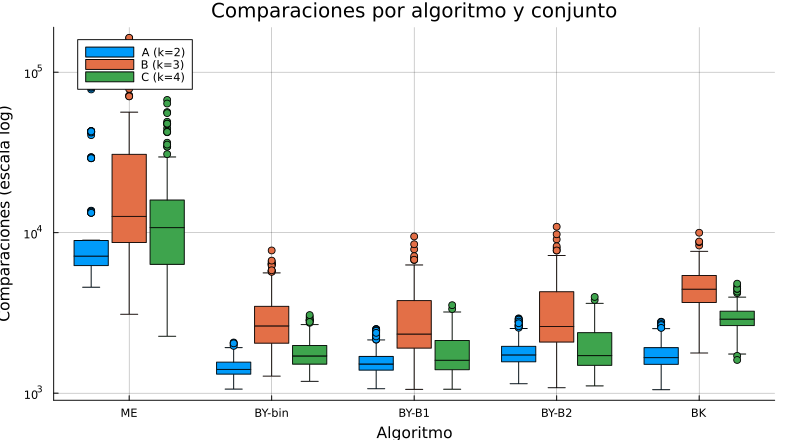

Figura 1: Comparaciones por algoritmo y conjunto (boxplot en escala logarítmica). Cada caja agrupa las 200 instancias de su conjunto.

```julia
colores = [:steelblue, :tomato, :seagreen, :darkorange, :mediumpurple]

# Construyo vectores de comparaciones agrupados (caja por algoritmo, color por conjunto)
function build_grouped(metric_field::Symbol)
    xs = String[]
    ys = Float64[]
    grupos = String[]
    for (sname, res) in [("A", res_A), ("B", res_B), ("C", res_C)]
        for a in ALGOS
            data = getfield(res, metric_field)[a]
            for v in data
                push!(xs, a)
                push!(ys, Float64(max(v, 1)))   # evitar 0 en escala log
                push!(grupos, sname)
            end
        end
    end
    return xs, ys, grupos
end

xs, ys, grupos = build_grouped(:cmps)

groupedboxplot(xs, ys, group=grupos,
    yscale  = :log10,
    label   = ["A (k=2)" "B (k=3)" "C (k=4)"],
    xlabel  = "Algoritmo",
    ylabel  = "Comparaciones (escala log)",
    title   = "Comparaciones por algoritmo y conjunto",
    legend  = :topleft,
    size    = (820, 460),
    grid    = true,
    gridalpha = 0.4)
```

Lo primero que se nota es que las cajas de **ME** son notablemente más altas que las de las variantes de BY y que las de BK. Esto se anticipaba en el análisis preliminar: como la mayoría de las instancias caen en régimen asimétrico ($n/m$ grande), el merge clásico paga el costo lineal $\mathcal{O}(m+n)$ aunque solo necesite encontrar unas pocas coincidencias. Las tres variantes de BY (bin, B1, B2) producen distribuciones muy parecidas, lo que tiene sentido porque el costo dominante viene de los $m$ pasos de divide y vencerás, no de la búsqueda interna que cada paso usa.

## Experimento 2 — Tiempo de ejecución por algoritmo y conjunto

Las comparaciones nos dicen cuánto trabajo “puro” hace cada algoritmo, pero al final lo que importa en un sistema real es el tiempo de ejecución. No siempre van de la mano: el comportamiento de caché y la sobrecarga de cada algoritmo pueden hacer que dos algoritmos con parecida cantidad de comparaciones tengan tiempos muy distintos. Para que las mediciones sean estables hago 3 repeticiones por instancia y me quedo con el mínimo, que es el criterio estándar en benchmarking porque descarta el ruido del sistema operativo (interrupciones, otros procesos, etc.).

```julia
# Tabla resumen de tiempos
println("Tiempos — mediana en µs por algoritmo y conjunto")
println("="^60)
print(@sprintf("%-10s", "Algoritmo"))
for nm in ["A (k=2)", "B (k=3)", "C (k=4)"]
    print(@sprintf("  %12s", nm))
end
println()
println("-"^60)
for a in ALGOS
    print(@sprintf("%-10s", a))
    for res in [res_A, res_B, res_C]
        print(@sprintf("  %12.2f", median(res.times[a])))
    end
    println()
end
```

```
Tiempos — mediana en µs por algoritmo y conjunto
============================================================
Algoritmo        A (k=2)       B (k=3)       C (k=4)
------------------------------------------------------------
ME                  6.00         11.60          9.50
BY-bin              4.80         10.65          8.00
BY-B1               4.50          8.90          7.30
BY-B2               4.80          9.80          7.90
BK                  4.30         13.15          8.50
```

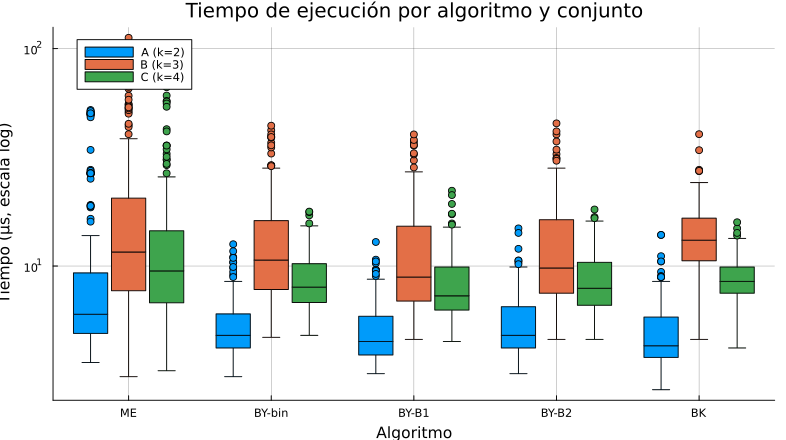

Figura 2: Tiempo de ejecución por algoritmo y conjunto (boxplot en escala logarítmica).

```julia
xs, ys, grupos = build_grouped(:times)

groupedboxplot(xs, ys, group=grupos,
    yscale  = :log10,
    label   = ["A (k=2)" "B (k=3)" "C (k=4)"],
    xlabel  = "Algoritmo",
    ylabel  = "Tiempo (µs, escala log)",
    title   = "Tiempo de ejecución por algoritmo y conjunto",
    legend  = :topleft,
    size    = (820, 460),
    grid    = true,
    gridalpha = 0.4)
```

Las tres variantes de BY siguen muy parejas entre sí, igual que en comparaciones. BK también se mantiene competitivo, aunque su sobrecarga por mantener cursores y sincronizar las $k$ listas le hace ceder ligeramente frente a BY en los conjuntos $B$ y $C$.

## Experimento 3 — Control: tamaño del resultado

Esta última gráfica funciona como un **control de validación**: como las cinco configuraciones deben producir exactamente la misma intersección, los boxplots del tamaño del resultado deben verse prácticamente idénticos para cada conjunto. Si alguno se desvía es señal de un bug que pasó por debajo de la validación inicial.

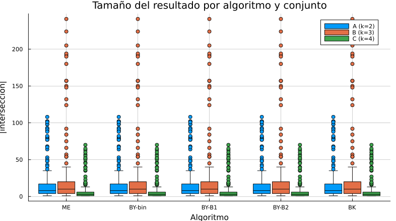

Figura 3: Tamaño del resultado por algoritmo y conjunto (gráfico de control). Las cajas deben ser idénticas entre algoritmos para un mismo conjunto.

```julia
xs, ys, grupos = build_grouped(:sizes)

groupedboxplot(xs, ys, group=grupos,
    label   = ["A (k=2)" "B (k=3)" "C (k=4)"],
    xlabel  = "Algoritmo",
    ylabel  = "|intersección|",
    title   = "Tamaño del resultado por algoritmo y conjunto",
    legend  = :topright,
    size    = (820, 460),
    grid    = true,
    gridalpha = 0.4)
```

Como esperaba, las cajas son idénticas algoritmo por algoritmo dentro de cada conjunto. Eso confirma que las cinco configuraciones están produciendo exactamente el mismo resultado en las 200 instancias, y por tanto que cualquier diferencia en tiempo o comparaciones se debe genuinamente al algoritmo y no a errores de implementación.

## Experimento 4 — Comparaciones vs. asimetría del problema

Para entender mejor el comportamiento de cada algoritmo, grafico el número de comparaciones contra el cociente $n/m$ (asimetría) de cada instancia del conjunto $A$. Esto debería revelar el cruce entre los regímenes: ME debería ganar cuando el cociente es bajo, y BY cuando es alto.

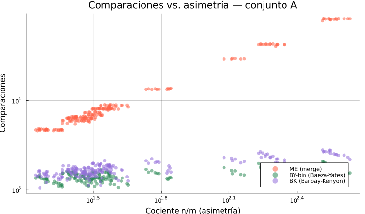

Figura 4: Comparaciones vs. cociente de tamaños n/m sobre el conjunto A (k=2). Cada punto es una instancia.

```julia
algos_a_graficar = ["ME", "BY-bin", "BK"]
colores_a = [:tomato, :seagreen, :mediumpurple]
etiquetas_a = ["ME (merge)", "BY-bin (Baeza-Yates)", "BK (Barbay-Kenyon)"]

plt = plot(xscale = :log10,
           yscale = :log10,
           xlabel = "Cociente n/m (asimetría)",
           ylabel = "Comparaciones",
           title  = "Comparaciones vs. asimetría — conjunto A",
           legend = :bottomright,
           size   = (780, 460),
           grid   = true,
           gridalpha = 0.4)

for (a, c, etiq) in zip(algos_a_graficar, colores_a, etiquetas_a)
    ys_a = max.(res_A.cmps[a], 1)
    scatter!(plt, ratios_A, ys_a,
             marker     = :circle,
             markersize = 4,
             markerstrokewidth = 0,
             color      = c,
             alpha      = 0.55,
             label      = etiq)
end
plt
```

Esta gráfica de dispersión muestra el comportamiento de tres algoritmos —ME, BY-bin y BK— como función de la asimetría $n/m$ de cada instancia. Cada punto es una de las 200 instancias del conjunto $A$.

# Discusión de resultados

## ¿La teoría y los datos coinciden?

[output not shown]

## Sobre las variantes de búsqueda en BY

Algo que me llamó la atención al ver los resultados es que las tres variantes de BY (binaria, $B_1$, $B_2$) producen distribuciones muy parecidas entre sí, tanto en comparaciones como en tiempos. Pensando por qué, creo que tiene sentido: el costo de BY está dominado por los $m$ pasos de divide y vencerás, no por la búsqueda interna que se ejecuta en cada paso. Las búsquedas no acotadas $B_1$ y $B_2$ son ligeramente más eficientes cuando la mediana cae cerca del punto donde se quedó la búsqueda anterior, pero en BY cada llamada parte desde una posición $sp$ que ya está acotada por las recursiones previas, así que el beneficio se diluye.

Para que $B_2$ realmente despegue se necesitan listas mucho más grandes o un patrón donde las búsquedas consecutivas estén correlacionadas espacialmente. Eso es justo lo que ocurre en algoritmos como BK, donde el cursor anterior es un buen predictor de la posición siguiente (Barbay et al. 2010), y por eso BK lo toma como búsqueda interna por defecto.

## Sobre el tradeoff comparaciones vs. tiempo

Otra cosa que vale la pena notar es que el número de comparaciones y el tiempo de ejecución no siempre van perfectamente alineados. ME hace muchas más comparaciones que BY en mediana, pero esa diferencia no se traduce 1-a-1 en tiempo porque el merge tiene acceso secuencial a memoria (favorable para la caché) y BY tiene acceso semi-aleatorio. En esta plataforma y con estos tamaños el efecto es modesto, pero sospecho que para listas que no caben en caché L2 el balance se estrecharía. Es algo que me gustaría medir en un experimento futuro con listas de millones de elementos.

# Conclusiones

Lo primero que rescato de este ejercicio es algo que ya intuía pero que no había visto tan claro hasta hacer los experimentos: el merge clásico, que en abstracto parece “el algoritmo natural” para intersectar listas ordenadas, en realidad solo es buena idea cuando los conjuntos tienen tamaños parecidos. En las posting lists reales que usé eso casi nunca ocurre. La asimetría mediana en los tres conjuntos fue de varias decenas, y en muchas instancias el cociente $n/m$ superaba el centenar. En ese régimen ME paga el costo lineal $\mathcal{O}(m+n)$ aunque la intersección sea de apenas un par de elementos, y eso se ve clarísimo en la Figura 1 donde las cajas de ME quedan muy por encima del resto.

El gráfico de control de la Figura 3 resultó más útil de lo que pensé al principio. Verlo idéntico para los cinco algoritmos en cada conjunto me dio mucha tranquilidad, porque en algún punto del desarrollo tuve un bug donde BK perdía algunos elementos por culpa de los duplicados consecutivos en las listas reales (cosa que la literatura no menciona explícitamente). Sin ese gráfico me hubiera costado mucho más detectarlo. Es una buena costumbre que me llevo para experimentos futuros: cuando varios algoritmos deberían dar el mismo resultado, vale la pena reportar el resultado también, no solo las métricas de rendimiento.

Una conexión con la unidad anterior que me dejó pensando: en la actividad 5.5 vi que $B_2$ no le ganaba a $B_1$ porque las listas eran muy chicas. Esperaba que acá, con listas más grandes, $B_2$ mostraría su ventaja. No sucedió, pero por una razón distinta: el contexto de uso (como búsqueda interna dentro de BY) no le permite explotar lo que la hace buena. Es un recordatorio útil de que la mejor cota asintótica no garantiza el mejor rendimiento práctico, depende de cómo y dónde se use el algoritmo.

# Referencias

Baeza-Yates, Ricardo. 2004. “A Fast Set Intersection Algorithm for Sorted Sequences”. En *Combinatorial Pattern Matching: 15th Annual Symposium, CPM 2004*, 3109:400–408. Lecture Notes en Computer Science. Springer. https://doi.org/10.1007/978-3-540-27801-6_30.

Barbay, Jérémy, Alejandro López-Ortiz, y Tyler Lu. 2006. “Faster Adaptive Set Intersections for Text Searching”. En *Experimental Algorithms: 5th International Workshop, WEA 2006*, 4007:146–57. Lecture Notes en Computer Science. Springer. https://doi.org/10.1007/11764298_13.

Barbay, Jérémy, Alejandro López-Ortiz, Tyler Lu, y Alejandro Salinger. 2010. “An Experimental Investigation of Set Intersection Algorithms for Text Searching”. *ACM Journal of Experimental Algorithmics* 14: 3.7:1–24. https://doi.org/10.1145/1498698.1564507.

Bentley, Jon Louis, y Andrew Chi-Chih Yao. 1976. “An Almost Optimal Algorithm for Unbounded Searching”. *Information Processing Letters* 5 (3): 82–87. https://doi.org/10.1016/0020-0190(76)90071-5.

Demaine, Erik D., Alejandro López-Ortiz, y J. Ian Munro. 2000. “Adaptive Set Intersections, Unions, and Differences”. En *Proceedings of the Eleventh Annual ACM-SIAM Symposium on Discrete Algorithms (SODA 2000)*, 743–52. SIAM.

Hwang, F. K., y S. Lin. 1971. “Optimal Merging of 2 Elements with n Elements”. *Acta Informatica* 1 (2): 145–58. https://doi.org/10.1007/BF00264025.

Téllez, Eric S. 2025. “Curso Introductorio al Análisis de Algoritmos con Julia, Capítulo 6: Algoritmos de intersección y unión de conjuntos en el modelo de comparación”. https://sadit.github.io/ALGO-IR/cap6-intersecciones.html.